# Campaign Impact Analysis

Prepared for the Head of Marketing

## Summary

- The Mens E-Mail campaign changed visit by +0.0766 (95% CI 0.0700 to 0.0832, adjusted p = <0.0001).
- The design could reliably detect effects of 0.0095 or larger; the observed effect is comfortably above that floor.
- On a confounded sample with known truth, an unadjusted comparison erred by +46.0% while adjusted estimators fell within 12.1%.
- Validity checks: Covariate balance passed; Group sizes passed; Parallel pre-trends not applicable.

## What was analysed

| Field | Value |
| --- | --- |
| Observations | 64,000 |
| Groups | No E-Mail (21,306); Womens E-Mail (21,387); Mens E-Mail (21,307) |
| Control group | No E-Mail |
| Outcome | visit |
| Covariates considered | recency, history, mens, womens, newbie, zip_code, channel |
| Significance level | 0.05 |
| Multiple-comparison correction | holm |
| Source | hillstrom.csv |
| Generated | 2026-07-30 16:26 +06 |

## Method selected

**Randomised experiment**

Randomised analysis is recommended. Propensity adjustment is also computable here, but adjusting a balanced experiment adds variance without removing bias — there is no confounding left for it to correct.

| Design | Supported | Reason |
| --- | --- | --- |
| Randomised experiment | yes | Treatment groups are balanced on all declared covariates, consistent with random assignment. Differences in outcomes can be attributed to the treatment. |
| Difference-in-differences | no | No period column is configured. Difference-in-differences compares change over time between groups, which requires observations from before and after the intervention. |
| Propensity-adjusted comparison | yes | Covariates are available to model group membership and adjust for measured differences. This corrects for imbalance in the variables you observed; it cannot correct for anything you did not measure. |

## Effect estimates

| Arm | Estimate | 95% CI | Relative lift | p (adjusted) | Detection floor (MDE) |
| --- | --- | --- | --- | --- | --- |
| Womens E-Mail | 0.0452 | 0.0389 – 0.0516 | +42.6% | <0.0001 | 0.0091 |
| Mens E-Mail | 0.0766 | 0.0700 – 0.0832 | +72.1% | <0.0001 | 0.0095 |

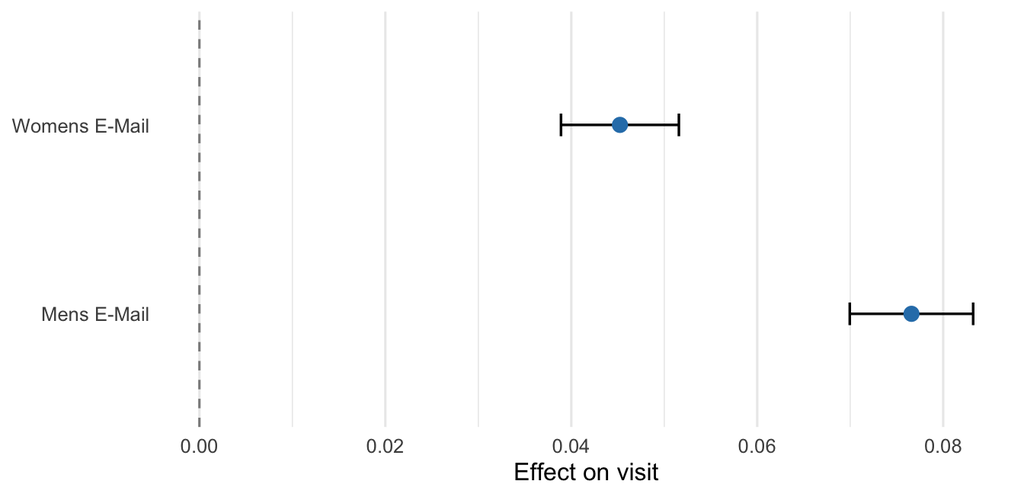

The detection floor is the smallest effect this design could reliably identify. An estimate close to that floor is statistically detectable but its magnitude is imprecisely measured — worth noting before budgeting against it.

### Probability readout

| Arm | Probability it beats control | Median difference | 95% credible interval |
| --- | --- | --- | --- |
| Womens E-Mail | 1.000 | 0.0452 | 0.0389 – 0.0516 |
| Mens E-Mail | 1.000 | 0.0766 | 0.0699 – 0.0832 |

Beta(1, 1) prior, 2e+05 draws, seed 42.

## Assumptions checked

[output not shown]

## How much can an unadjusted comparison mislead?

The randomised data gives a known true effect. A biased subsample of 21,333 observations was then drawn where retention depends on recency and history, deliberately breaking the random assignment. Each estimator was run on that subsample and scored against the truth.

This sample is constructed, not observed. It exists to test whether the adjustment methods recover an answer that is already known.

| Estimator | Estimate | True effect | Error | 95% CI | Interval covers truth |
| --- | --- | --- | --- | --- | --- |
| Naive comparison | 0.1118 | 0.0766 | +46.0% | 0.1025 – 0.1212 | no |
| IPW | 0.0811 | 0.0766 | +5.9% | 0.0675 – 0.0948 | yes |
| AIPW (doubly robust) | 0.0859 | 0.0766 | +12.1% | 0.0721 – 0.0997 | yes |

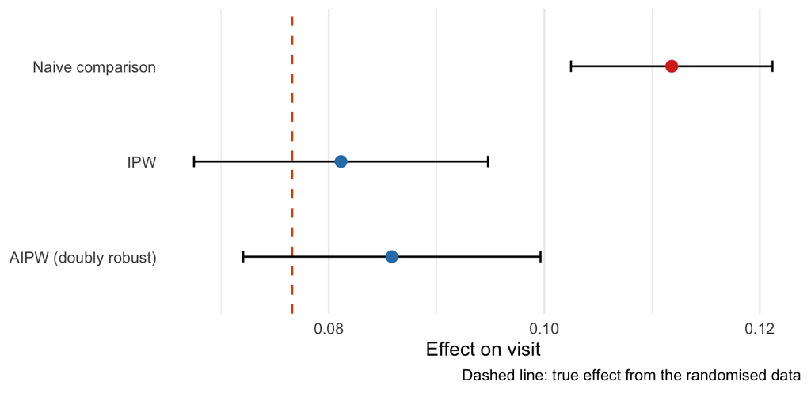

**Common support: fail.** Propensity overlap is poor: 0.4% of units fall outside the shared range and the largest stabilised weight is 50.1. Some units have no comparable counterpart in the other group, so the adjusted estimate depends on extrapolation the data does not support.

## Notes on interpretation

- An estimate is only as good as the assumption that identifies it. This report states which assumptions were checked and which failed.
- Where a validity check fails, the estimate is still shown but should not be treated as reliable without addressing the cause.
- Adjustment corrects for measured differences between groups. It cannot correct for anything that was not measured.